“Prosper Loan Data Exploration” Saeid Rostami ========================================================

# Summary of Data

```
## [1] 113937
```

```
## [1] 81
```

Prosper which was founded in 2005 is a peer-to-peer lending platform that people can invest in each other. Prosper connects people who need money with those who have money to invest. Prosper loan data contain 113,937 rows with 81 columns.

```
##  [1] "ListingKey"
##  [2] "ListingNumber"
##  [3] "ListingCreationDate"
##  [4] "CreditGrade"
##  [5] "Term"
##  [6] "LoanStatus"
##  [7] "ClosedDate"
##  [8] "BorrowerAPR"
##  [9] "BorrowerRate"
## [10] "LenderYield"
## [11] "EstimatedEffectiveYield"
## [12] "EstimatedLoss"
## [13] "EstimatedReturn"
## [14] "ProsperRating..numeric."
## [15] "ProsperRating..Alpha."
```

[output cut: 66 more lines]

# Creating new dataframe based on prosper data

```
## 'data.frame':    113937 obs. of  13 variables:
##  $ DelinquenciesLast7Years : int  4 0 0 14 0 0 0 0 0 0 ...
##  $ PublicRecordsLast10Years: int  0 1 0 0 0 0 0 1 0 0 ...
##  $ DaysWithCreditLine      : num  6241 8274 5952 13041 5379 ...
##  $ InquiriesLast6Months    : int  3 3 0 0 1 0 0 3 1 1 ...
##  $ BorrowerRate            : num  0.158 0.092 0.275 0.0974 0.2085 ...
##  $ Term                    : Factor w/ 3 levels "12","36","60": 2 2 2 2 2 3 2 2 2 2 ...
##  $ ProsperRating           : Factor w/ 7 levels "AA","A","B","C",..: NA 2 NA 2 5 3 6 4 1 1 ...
##  $ ListingCreationDate     : Factor w/ 113064 levels "2005-11-09 20:44:28.847000000",..: 14184 111894 6429 64760 85967 100310 72556 74019 97834 97834 ...
##  $ LoanOriginalAmount      : int  9425 10000 3001 10000 15000 15000 3000 10000 10000 10000 ...
##  $ ListingCategory         : Factor w/ 21 levels "Not available",..: 1 3 1 17 3 2 2 3 8 8 ...
##  $ EmploymentStatus        : Factor w/ 9 levels "","Employed",..: 9 2 4 2 2 2 2 2 2 2 ...
##  $ AnnualIncome            : num  37000 73500 25000 34500 115000 ...
##  $ RevolvingCreditBalance  : num  0 3989 NA 1444 6193 ...
```

```
##  DelinquenciesLast7Years PublicRecordsLast10Years DaysWithCreditLine
##  Min.   : 0.000          Min.   : 0.0000          Min.   : 2151
##  1st Qu.: 0.000          1st Qu.: 0.0000          1st Qu.: 6817
##  Median : 0.000          Median : 0.0000          Median : 8412
##  Mean   : 4.155          Mean   : 0.3126          Mean   : 8761
##  3rd Qu.: 3.000          3rd Qu.: 0.0000          3rd Qu.:10391
##  Max.   :99.000          Max.   :38.0000          Max.   :26013
##  NA's   :990             NA's   :697              NA's   :697
##  InquiriesLast6Months  BorrowerRate    Term       ProsperRating
##  Min.   :  0.000      Min.   :0.0000   12: 1614   C      :18345
##  1st Qu.:  0.000      1st Qu.:0.1340   36:87778   B      :15581
##  Median :  1.000      Median :0.1840   60:24545   A      :14551
##  Mean   :  1.435      Mean   :0.1928              D      :14274
##  3rd Qu.:  2.000      3rd Qu.:0.2500              E      : 9795
##  Max.   :105.000      Max.   :0.4975              (Other):12307
##  NA's   :697                                      NA's   :29084
##                     ListingCreationDate LoanOriginalAmount
##  2013-10-02 17:20:16.550000000:     6   Min.   : 1000
##  2013-08-28 20:31:41.107000000:     4   1st Qu.: 4000
##  2013-09-08 09:27:44.853000000:     4   Median : 6500
##  2013-12-06 05:43:13.830000000:     4   Mean   : 8337
##  2013-12-06 11:44:58.283000000:     4   3rd Qu.:12000
##  2013-08-21 07:25:22.360000000:     3   Max.   :35000
##  (Other)                      :113912
##            ListingCategory       EmploymentStatus  AnnualIncome
##  Debt consolidation:58308   Employed     :67322   Min.   :       0
##  Not available     :16965   Full-time    :26355   1st Qu.:   38404
##  Other             :10494   Self-employed: 6134   Median :   56000
##  Home improvement  : 7433   Not available: 5347   Mean   :   67296
##  Business          : 7189   Other        : 3806   3rd Qu.:   81900
##  Auto              : 2572                : 2255   Max.   :21000035
##  (Other)           :10976   (Other)      : 2718
##  RevolvingCreditBalance
##  Min.   :      0
##  1st Qu.:   3121
##  Median :   8549
##  Mean   :  17599
##  3rd Qu.:  19521
##  Max.   :1435667
##  NA's   :7604
```

# Univariate Plots Section

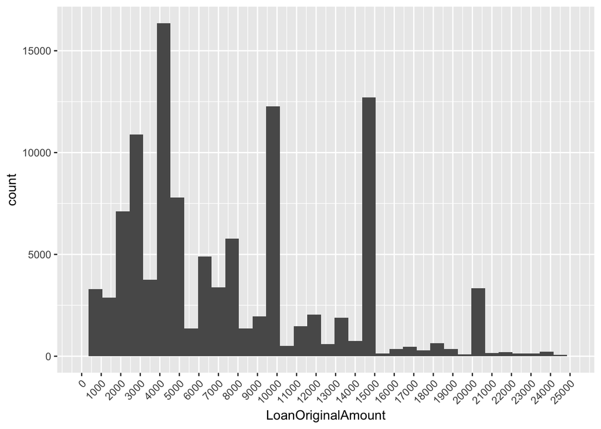

From the figure above we can see the amont of money that people borrow and as we can see people tend to borrow in whole numbers.

```
##    Min. 1st Qu.  Median    Mean 3rd Qu.    Max.
##    1000    4000    6500    8337   12000   35000
```

The minimum money that people borrowed is 1000 as opposed to maximum, which is 35000. the median and mean are 6500 and 8337 respectively.

## Loan category

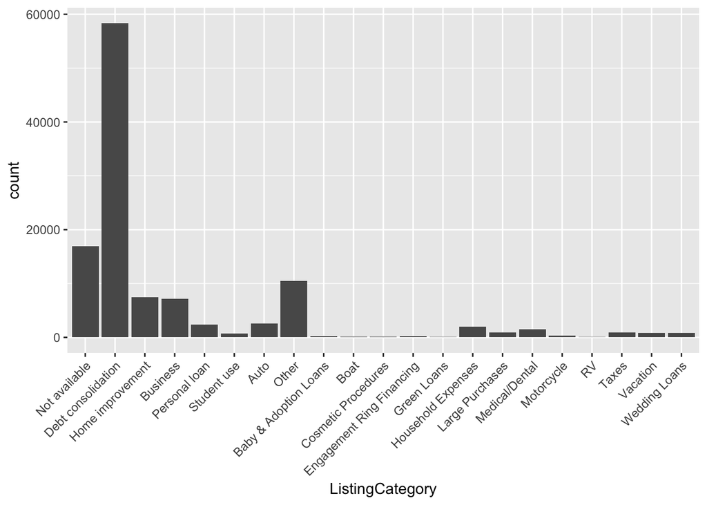

Sounds like most people borrow to cover their debts.

## Employment status

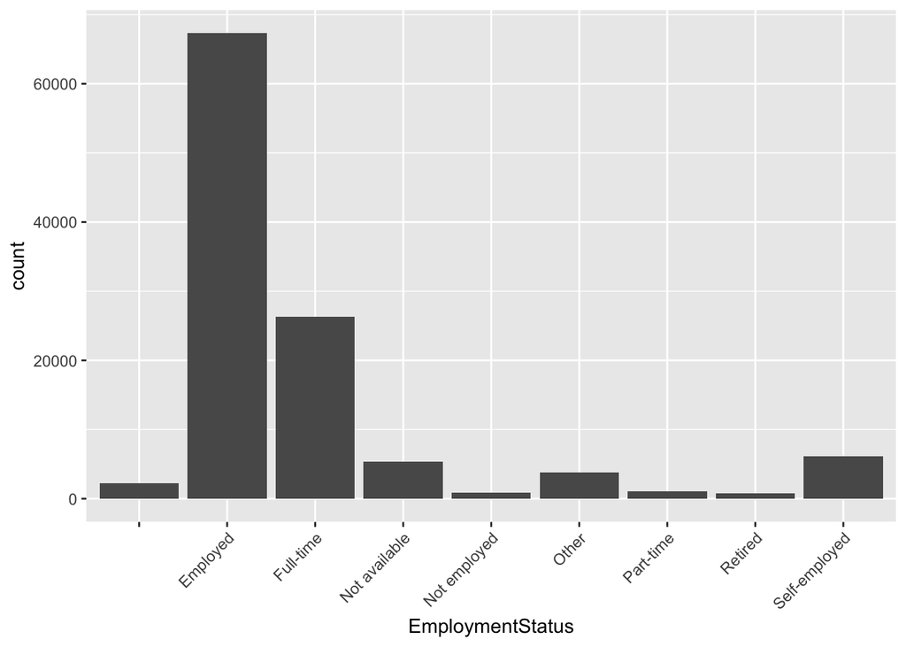

As we can see most of the borrowers are employed.

## Income status

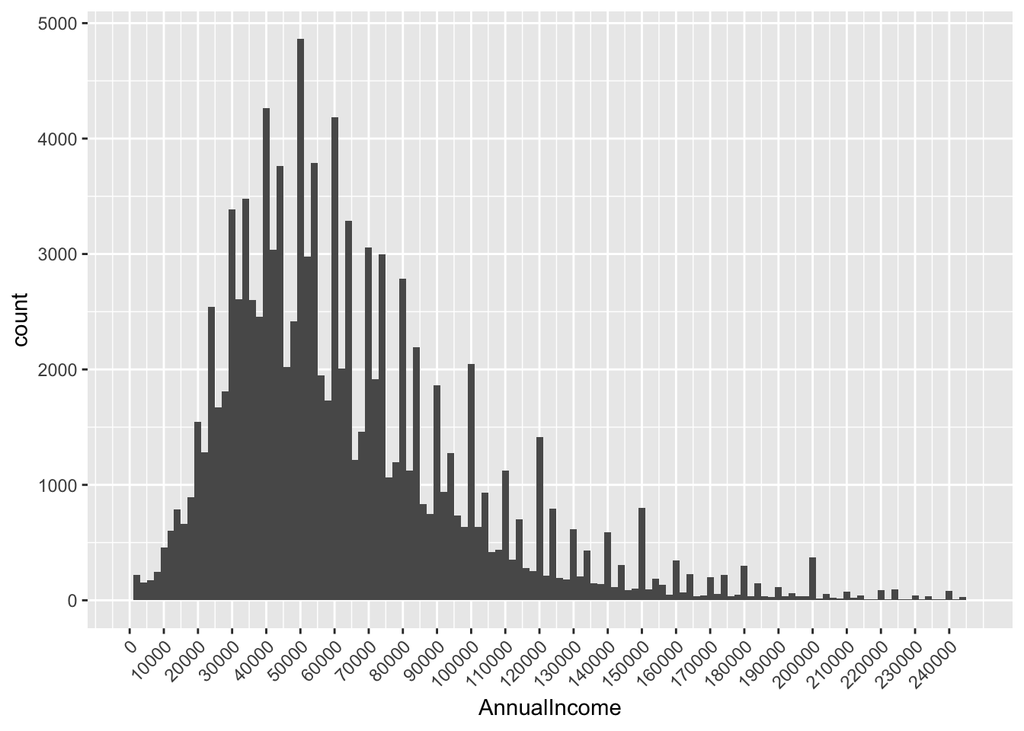

```
##     Min.  1st Qu.   Median     Mean  3rd Qu.     Max.
##        0    38404    56000    67296    81900 21000035
```

The majority of income are between 20000 and 90000 annually. The median is 56000 and the mean is 67296.

## Payment history

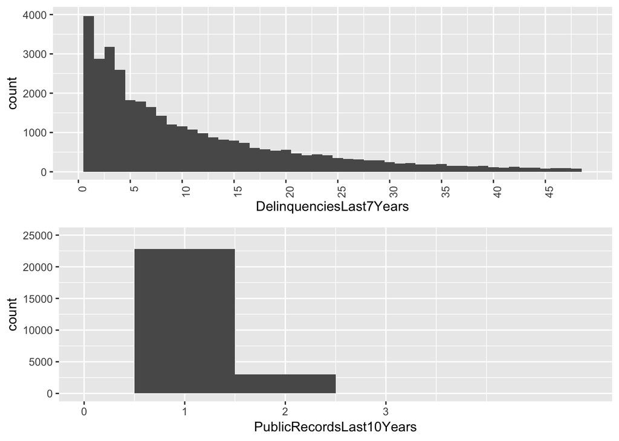

```
##    Min. 1st Qu.  Median    Mean 3rd Qu.    Max.    NA's
##   0.000   0.000   0.000   4.155   3.000  99.000     990
```

```
##    Min. 1st Qu.  Median    Mean 3rd Qu.    Max.    NA's
##  0.0000  0.0000  0.0000  0.3126  0.0000 38.0000     697
```

It is obvious that most of the borrower have zero or one deliquencies in the last 7 years. Similarly they have zero or one public records in the last 10 years.

## Revolving Credit Balance

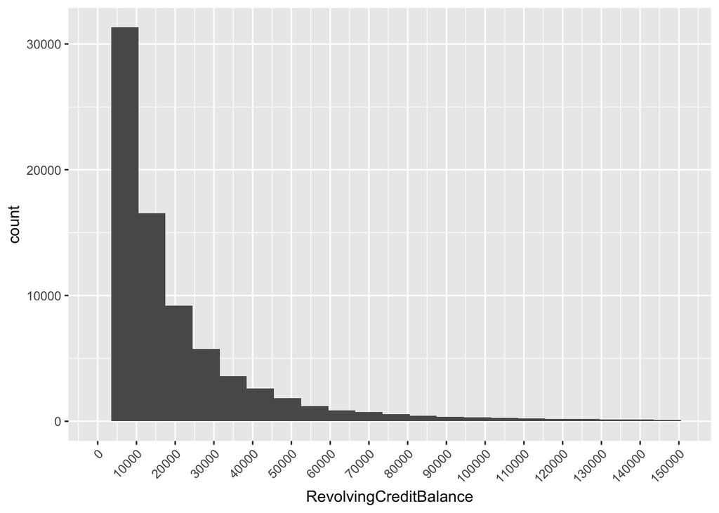

```
##    Min. 1st Qu.  Median    Mean 3rd Qu.    Max.    NA's
##       0    3121    8549   17599   19521 1435667    7604
```

Revolving Credit Balance is the total outstanding balance that the borrower owes on his/her credit accounts. The median and mean are 8549 and 17600 respectively and the most common amount is 0.

## Length of credit history

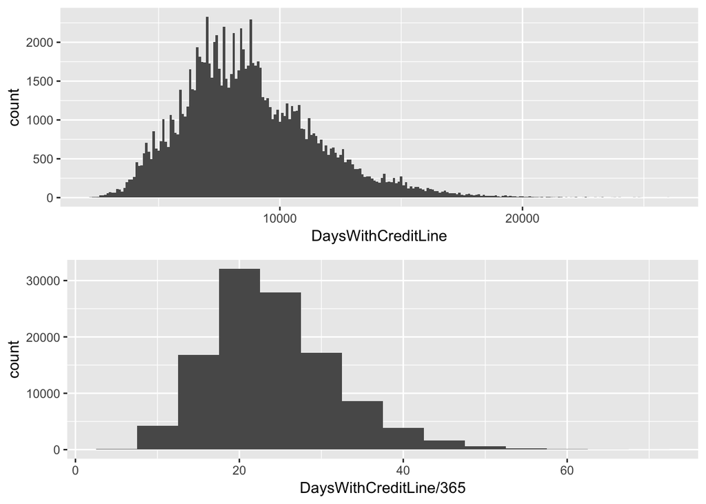

here is a credit line stors the credit story of 60 years.

## Rating

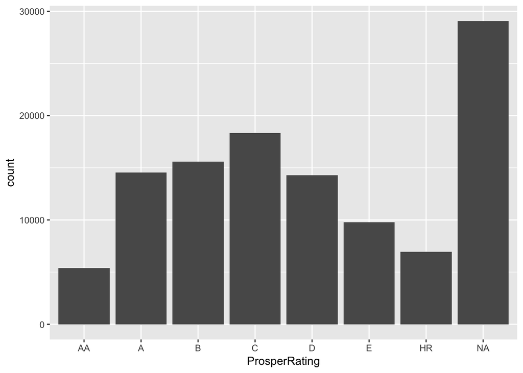

The most common rating is C follows by B. A and D are at the next steps (excluding the NA).

## Loan length

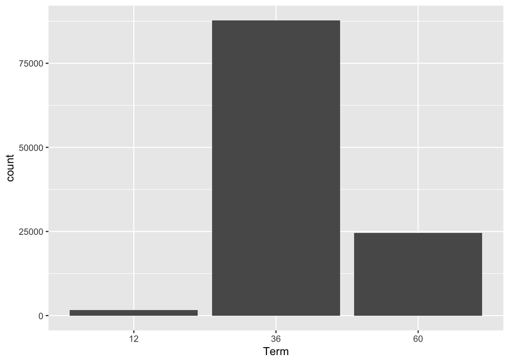

Most loans have 36 months terms

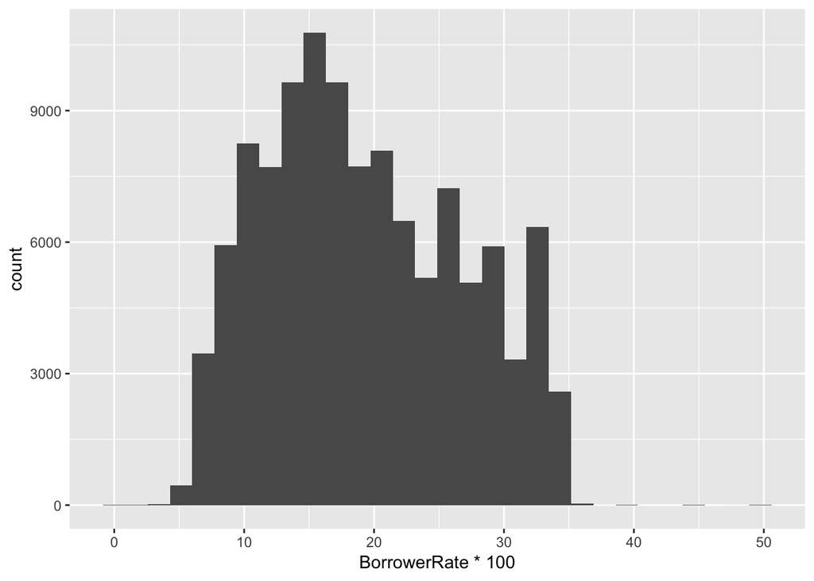

```
##    Min. 1st Qu.  Median    Mean 3rd Qu.    Max.
##  0.0000  0.1340  0.1840  0.1928  0.2500  0.4975
```

The median and mean for the borrower rate are 18.4% and 19.28% respectively, and The maximum borrower rate is 0.4975 or 49.75%.

## Years borrowing

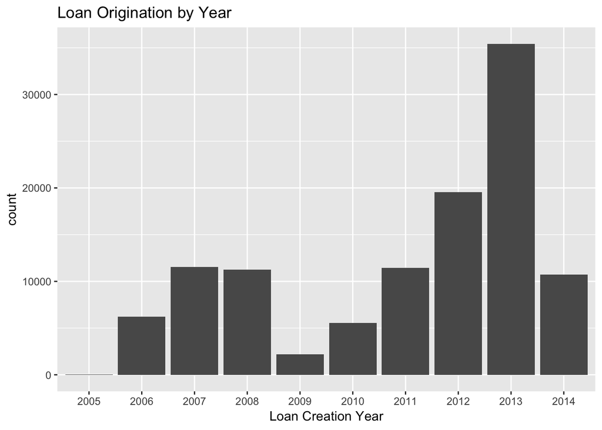

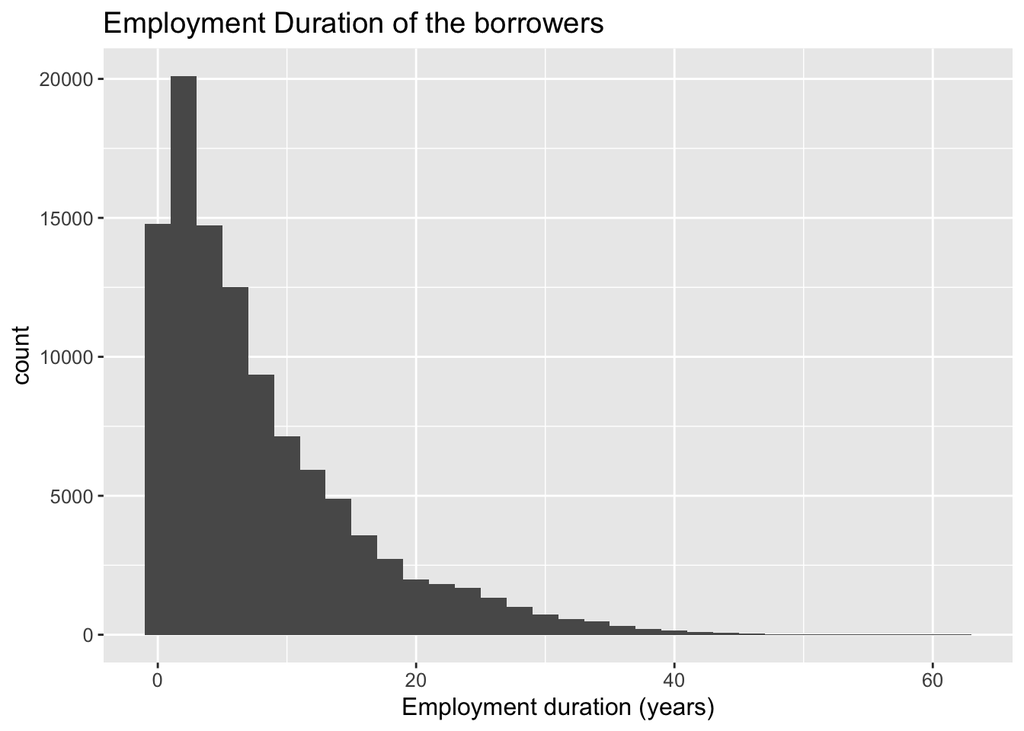

With the increase of the length of employment there is a decreas in the number of people who borrow loans.

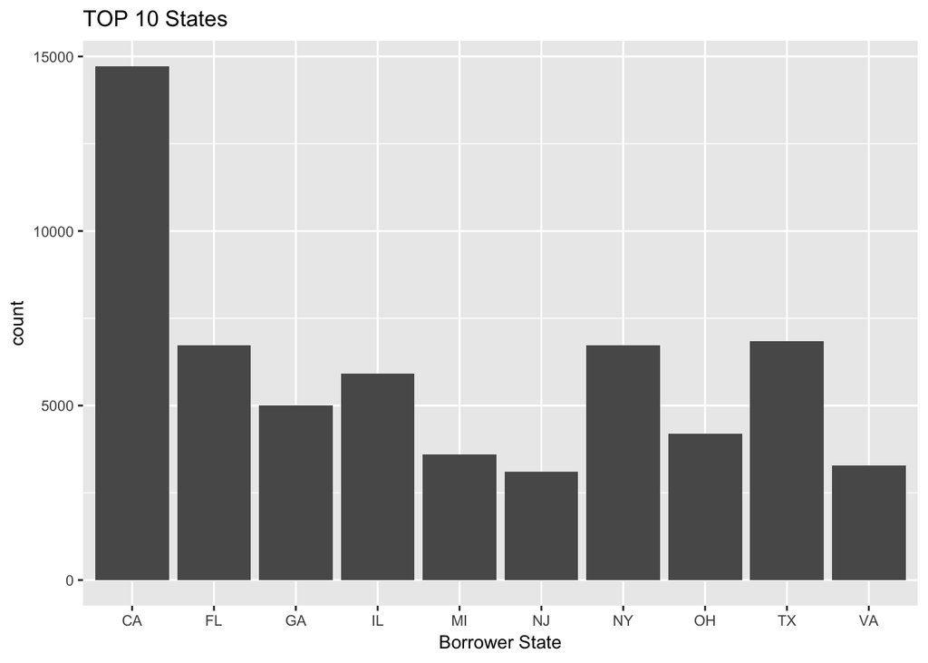

As we can see California is the state that people were more likely to loan and Florida, Illinois, New York and Texas are at the next steps.

# Univariate Analysis

### What is the structure of your dataset?

For the purpose of this project I am using the Prosper data set, which contains all Prosper loans created until March 11th, 2014. There are discrete and continuous variables in this dataset.Each variable is a column and each row is an observation.

### What is/are the main feature(s) of interest in your dataset?

- DelinquenciesLast7Years
- PublicRecordsLast10Years
- DebtToIncomeRatio
- RevolvingCreditBalance
- DaysWithCreditLine
- LoanOriginalAmount
- ListingCategory
- EmploymentStatus
- AnnualIncome
- BorrowerRate
- Term
- ProsperRating
- Listing Creation Date

### What other features in the dataset do you think will help support your investigation into your feature(s) of interest?

Other variables that help me in my investigation are Employment Duration, Debt To Income Ratio, Prosper Rating and Occupation.

### Did you create any new variables from existing variables in the dataset?

I created following new variables during the analysis: ListingCretionYear and Days with credit line.

### Of the features you investigated, were there any unusual distributions? Did you perform any operations on the data to tidy, adjust, or change the form of the data? If so, why did you do this?

I set ListingCreationYear variable as a factor so when I plotted it would look discrete. I’ve alose taked care of ranked variables order in top 10 loan states.

# Bivariate Plots Section

## The relationship between Loan Original Amount and Number of

Investors

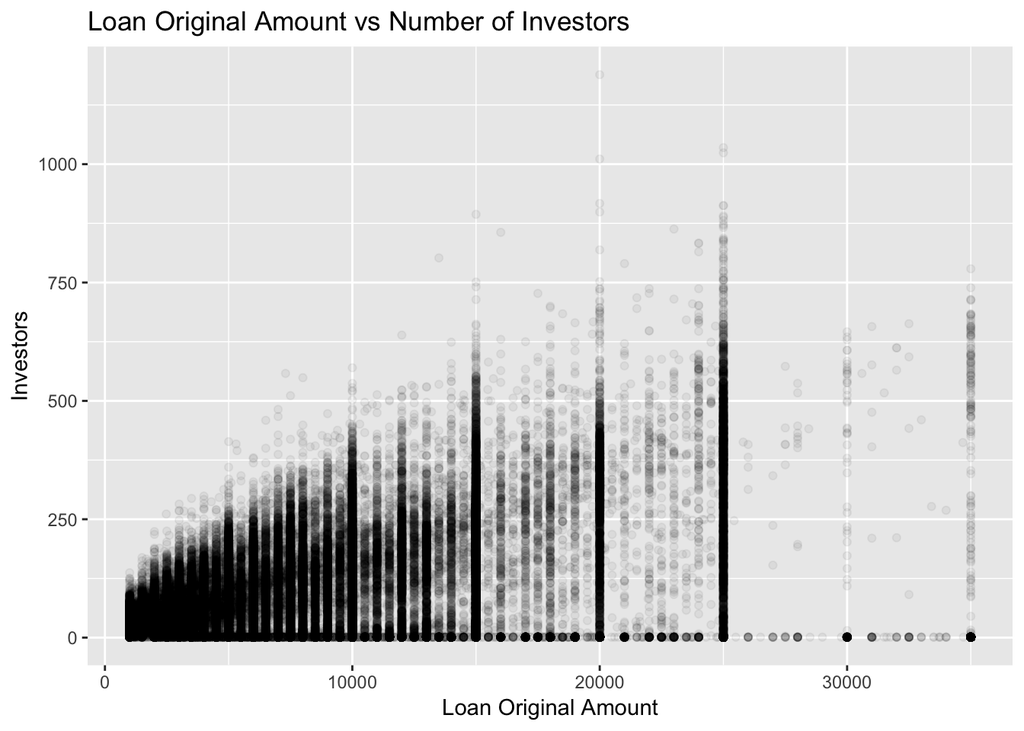

As we can see larger loans have more investors.

## Borrowed loan amount vary trought the years

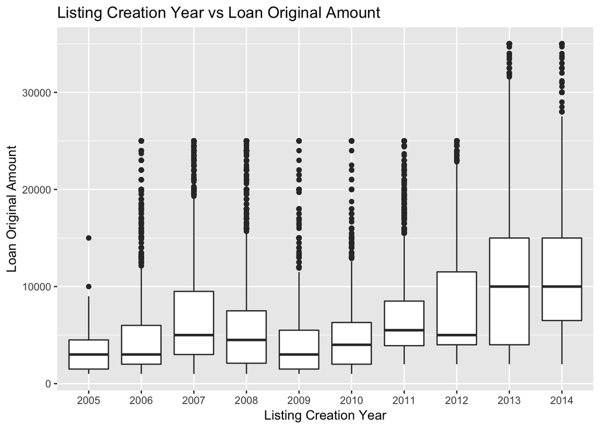

Mean loans amounts wen up slowly from 2005 to 2007, then it decreased at 2008 and went down to his minimum value at 2009. After that it recovered and increased and peaked at 2013 and 2014.

## Relationship between loan amount and terms.

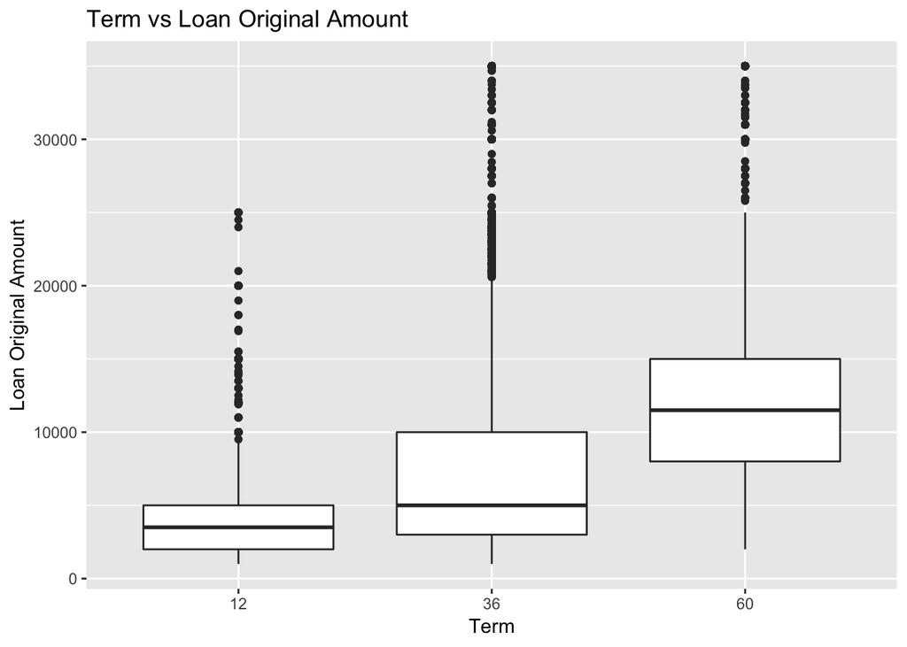

```
## df$Term: 12
##    Min. 1st Qu.  Median    Mean 3rd Qu.    Max.
##    1000    2000    3500    4694    5000   25000
## --------------------------------------------------------
## df$Term: 36
##    Min. 1st Qu.  Median    Mean 3rd Qu.    Max.
##    1000    3000    5000    7276   10000   35000
## --------------------------------------------------------
## df$Term: 60
##    Min. 1st Qu.  Median    Mean 3rd Qu.    Max.
##    2000    8000   11500   12370   15000   35000
```

The loan amonts are getting larger with longer terms. As we can see from the Table median and mean are increasing by longer terms.

## Relationships between loan amount and the IncomeRange

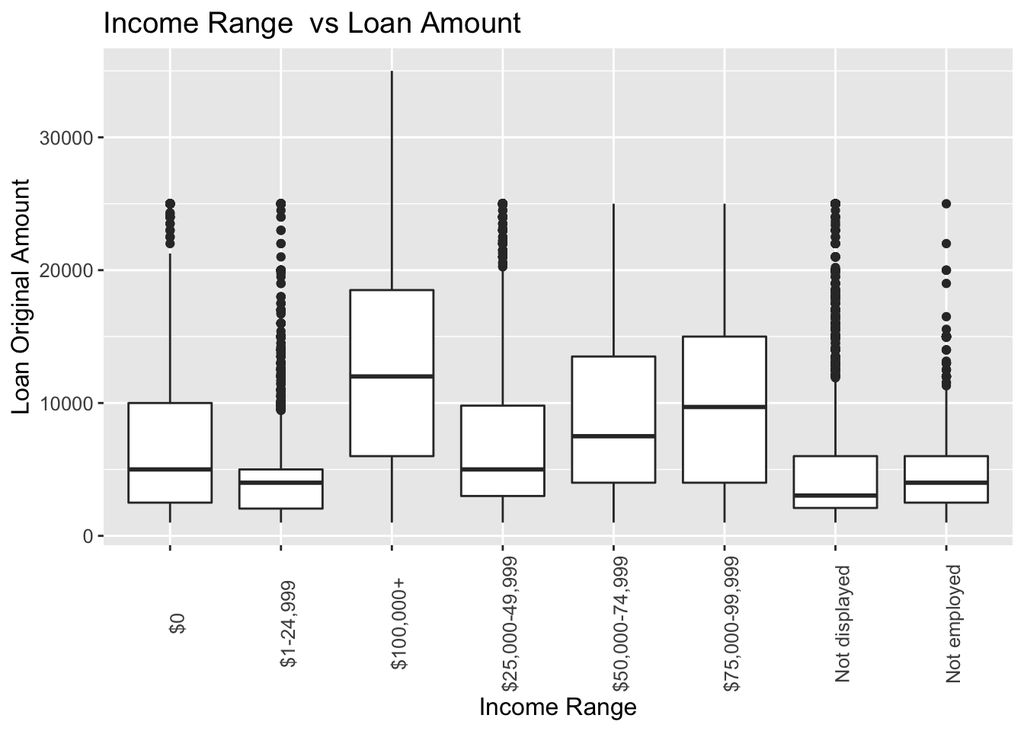

It is obvious from the box pots that larger loans on average are related to larger incomes.

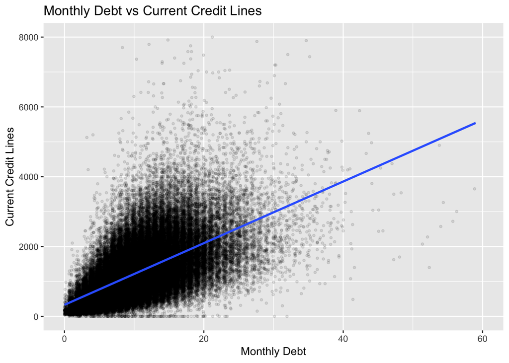

As we can see the amonth of debt is growing by increasing the number of credit lines.

## Relationship between LoanOriginalAmount with ListingCategory.

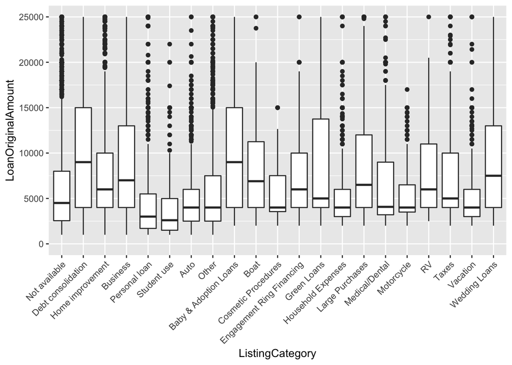

## Employment status and loan amount

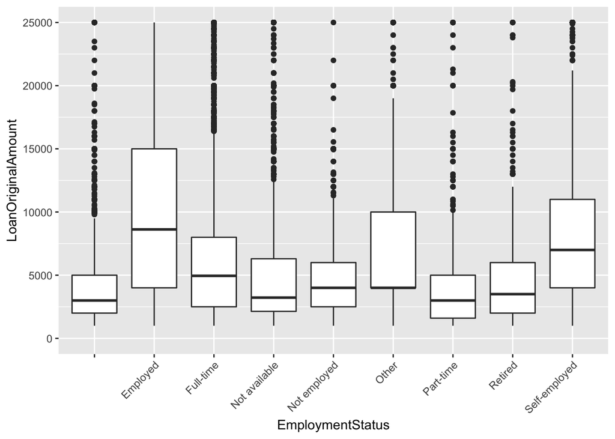

As we can see Employed people requested more loans. Interestingly, Not employed people wanted more loan than part-time employed people.

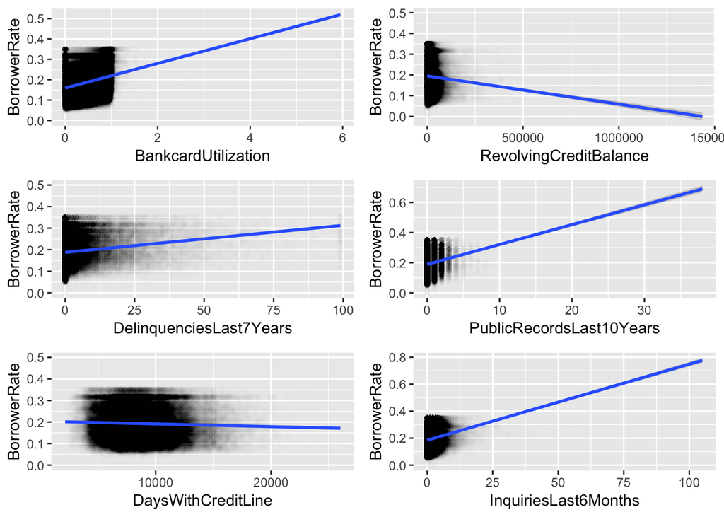

As BankcardUtilization, DeliquenciesLast7Years, PublicRecordsLast10Years and InquiriesLast6Months increaseswith the borrower rate,as opposed to RevolvingCreditBalance, whcih decreased. DaysWithCreditLine has no significant change with BorrowerRate.

## Correlation between BorrowerRate with BankcardUtilization:

```
## [1] 0.255482
```

## Correlation between BorrowerRate with RevolvingCreditBalance:

```
## [1] -0.05960823
```

## Correlation between BorrowerRate with DelinquenciesLast7Years:

```
## [1] 0.1702787
```

## Correlation between BorrowerRate with PublicRecordsLast10Years:

```
## [1] 0.1283138
```

## Correlation between BorrowerRate with DaysWithCreditLine:

```
## [1] -0.0474466
```

## Correlation between BorrowerRate with InquiriesLast6Months:

```
## [1] 0.18381
```

None of that variebles has strong relatipnship with each other. The strongest relationship is between BorrowerRate with BankcardUtilization with 0.25.

## Relation of Term and AnnualIncome

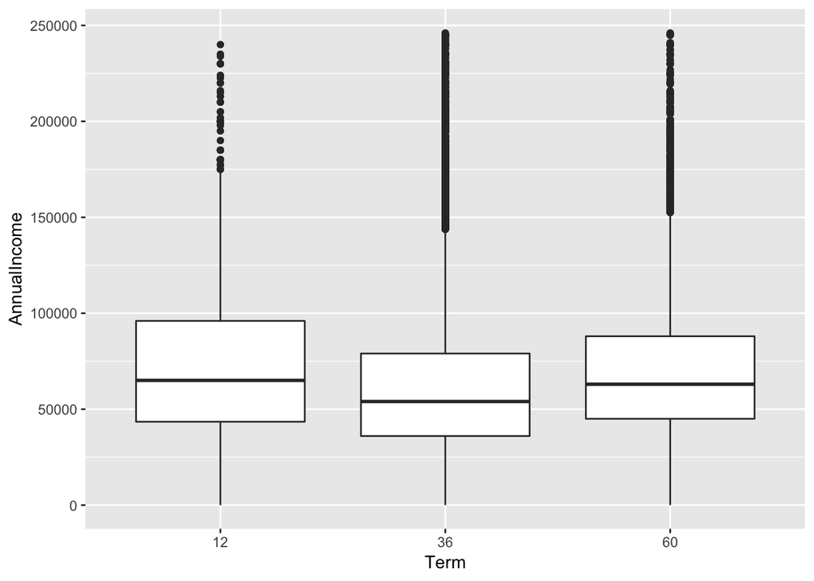

```
##    Min. 1st Qu.  Median    Mean 3rd Qu.    Max.
##       0   44200   67000   82658   97925 7422574
```

```
##     Min.  1st Qu.   Median     Mean  3rd Qu.     Max.
##        0    36000    54000    65289    80000 21000035
```

```
##    Min. 1st Qu.  Median    Mean 3rd Qu.    Max.
##       0   45000   64000   73465   90000 1305000
```

The median and mean for 12 months term are the highest between term of 12,36 and 60.

## Relation betwen Term and DeptToIncomeRatito

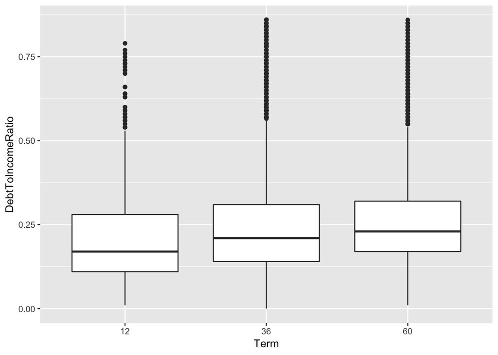

```
##    Min. 1st Qu.  Median    Mean 3rd Qu.    Max.    NA's
##  0.0100  0.1100  0.1700  0.2203  0.2800 10.0100     199
```

```
##    Min. 1st Qu.  Median    Mean 3rd Qu.    Max.    NA's
##   0.000   0.140   0.210   0.283   0.310  10.010    6953
```

```
##    Min. 1st Qu.  Median    Mean 3rd Qu.    Max.    NA's
##  0.0100  0.1700  0.2300  0.2565  0.3200 10.0100    1402
```

As we can see the median of the DebtToIncomeRatio increases as the terms goes up.

## ProsperRating against BorrowerRate

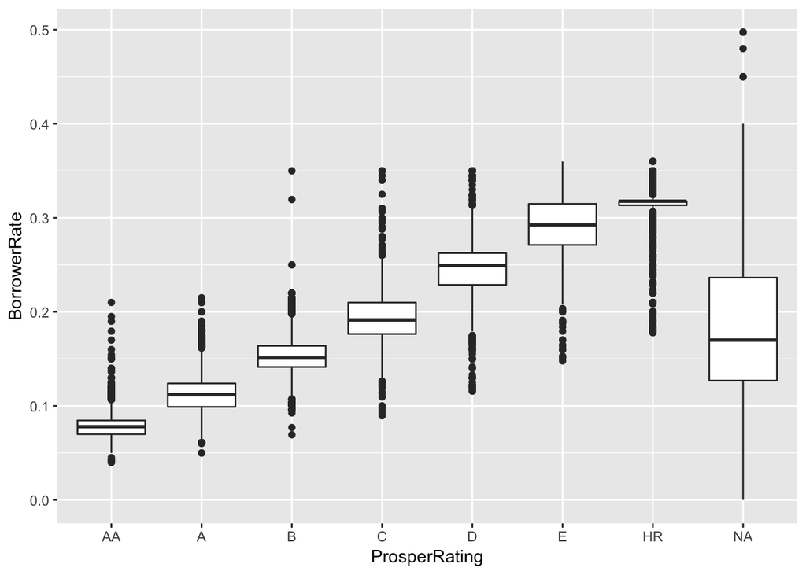

As we can see The better rating belongs to lower borrower rate.

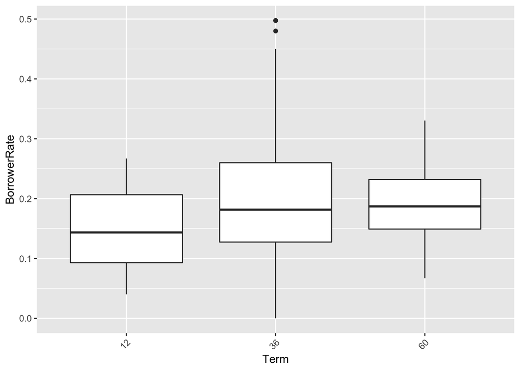

The median of 60 month term is the highest one, while the 12 month has the minimum one.

# Bivariate Analysis

### What was the strongest relationship you found?

# Multivariate Analysis

# Final Plots and Summary

# Reflection